# Downstream RNA-seq Analysis of Pig Liver Response to Oxidized Oil and Phytogenic Feed Additive

Workflow Design Group 4

2026-04-17

# Downstream RNA-seq Analysis of Pig Liver Response to Oxidized Oil and Phytogenic Feed Additive

**Project:** Workflow Design Group 4, reproducible Nextflow RNA-seq workflow  
**Reference:** Le Coz et al. (2021), *Frontiers in Veterinary Science*, DOI: 10.3389/fvets.2021.650732

## Executive Summary

This report describes the downstream RNA-seq analysis implemented in the project repository and how it relates to the liver transcriptome analysis of Le Coz et al. (2021). The biological question is whether a phytogenic feed additive (PFA) can partially counteract the liver transcriptomic response caused by an oxidized oil (OO) dietary challenge in weaned piglets.

The key downstream result in the paper was that a likelihood-ratio test identified 2,762 genes whose liver expression changed across four diets. These were grouped into six expression clusters. Cluster 1 contained 279 genes strongly induced by oxidized oil and partially reduced when PFA was added. Functional enrichment pointed to lipid oxidation, fatty acid oxidation, and peroxisome-related biology. The local workflow recreates this logic and generates a Figure 2A-style cluster plot and a Figure 2B-style GO enrichment barplot.

## Biological and Experimental Context

Phytogenic feed additives are plant-derived products used in animal nutrition as possible alternatives to antibiotic growth promoters. This analysis focuses on the liver RNA-seq component, using 24 paired-end libraries from four dietary groups of weaned piglets over 28 days: control (CTR), phytogenic additive alone (PFA), oxidized oil alone (OO), and oxidized oil plus additive (PFA_OO), with six animals per group.

The four-group design separates two questions: the CTR-vs-OO contrast captures the oxidative-oil impact, while the OO-vs-PFA_OO contrast captures whether the additive modifies that response under challenge. The PFA group distinguishes general additive effects from challenge-specific ones. The liver is the appropriate tissue because it centrally handles dietary lipids, detoxification, and metabolic stress signals. Oxidized lipids can increase pressure on fatty-acid oxidation, antioxidant defense, and peroxisomal processes.

| Group | Meaning | Liver RNA-seq samples |
| --- | --- | --- |
| CTR | Control diet | 6 |
| PFA | Control + phytogenic additive | 6 |
| OO | Oxidized oil diet | 6 |
| PFA_OO | Oxidized oil + phytogenic additive | 6 |

## Analysis Objective

The downstream analysis has four linked goals: obtain a clean count matrix with matched condition labels; detect genes differing across diets using a count-appropriate statistical model; group significant genes by expression pattern; and annotate the most relevant cluster with functional enrichment. The workflow converts gene-level counts into a reproducible biological statement: oxidized oil creates a strong hepatic transcriptional response in lipid metabolism and oxidative pathways, while the phytogenic additive reduces part of that response.

The most important deviation from the paper is using STAR GeneCounts instead of a separate HTSeq counting step, chosen for reduced intermediate file size. Exact gene-level counts may therefore not be numerically identical to the publication, though the analytical logic is preserved.

## Data Inputs and Workflow Position

The pipeline uses the *Sus scrofa* Sscrofa11.1 genome and Ensembl release 111 annotation. STAR alignment with `--quantMode GeneCounts` produces gene-level counts during alignment, selecting the reverse-stranded column for this stranded library. Per-sample count files are merged into `raw_counts_matrix.txt`. Sample metadata are drawn from `metadata/SraRunTable.csv`, a curated SRA Run Selector export for BioProject PRJNA669819.

The workflow progresses as follows: FastQC → STAR alignment and counting → count matrix merging → alignment statistics parsing → downstream R-based differential expression, clustering, and enrichment. This modular structure isolates quality control, alignment, counting, and interpretation as separate debuggable layers.

The count matrix uses Ensembl gene IDs, which must be converted to Entrez IDs before calling `enrichGO`. This conversion is a fragile point because unmapped genes silently reduce the enrichment input. The workflow therefore writes the mapping table used for cluster 1, allowing later inspection.

## Downstream Analysis Design

### Metadata Construction

After filtering, the workflow intersects count-matrix columns, metadata rows, and passing samples to prevent silent mismatches. The condition factor is ordered CTR → PFA → OO → PFA_OO. Condition labels are derived directly from SRA metadata using the run accession as the shared key, minimizing label-swap risk.

### Differential Expression Model

DESeq2 is run with design `~ condition` and a likelihood-ratio test comparing the full model to an intercept-only reduced model. This tests whether each gene shows any expression change across the four diets, mirroring the liver strategy in Le Coz et al. Genes with adjusted p-value below 0.1 are retained for clustering. The negative-binomial model accounts for overdispersion typical of RNA-seq count data, and the LRT is well suited here because it evaluates the condition term as a whole without pre-specifying a single pairwise contrast, which is exactly what is needed before pattern-based clustering.

### Transformation and Clustering

Significant genes are ordered by raw p-value and the top 2,762 are selected, matching the paper’s reported count. A variance-stabilizing transformation is applied before clustering to remove the mean-variance relationship that would otherwise allow high-count genes to dominate distance structure. These transformed, per-gene-scaled values are passed to DEGreport’s `degPatterns` function (minimum cluster size 50), producing `recreated_clusters.csv`. Scaling emphasizes relative expression patterns rather than absolute abundance, which is appropriate when the central question is whether genes move together across conditions.

### Functional Enrichment

Cluster 1 genes are mapped from Ensembl to Entrez IDs using the NCBI gene2ensembl table — chosen over BioMart for automation stability — then passed to clusterProfiler with `org.Ss.eg.db`, ontology ALL, and Benjamini-Hochberg-adjusted q-value and p-value cutoffs of 0.1. If no terms are enriched, the workflow writes an explicit informative message rather than failing silently.

Enrichment identifies GO categories overrepresented in cluster 1 relative to the genomic background. Results should be read as structured biological clues, not mechanistic proof: GO terms are not independent, annotation quality varies, and mapping success affects which genes enter the test. The enrichment is most interpretable here precisely because the expected biology — hepatic lipid handling under oxidized-oil challenge — aligns directly with the enriched terms.

## Downstream Data Flow Summary

| Stage | Input | Method | Output |
| --- | --- | --- | --- |
| Count matrix construction | Per-sample STAR GeneCounts | Merge across samples | `raw_counts_matrix.txt` |
| Sample filtering | STAR final log files | Unique mapping % threshold | Passing sample list |
| Metadata alignment | SRA Run Table + count columns | Intersection by run accession | DESeq2-compatible sample table |
| Differential expression | Count matrix + sample table | DESeq2 LRT | Significant genes across diets |
| Clustering | VST matrix for selected genes | DEGreport `degPatterns` | Cluster assignments + Figure 2A |
| Functional enrichment | Cluster 1 gene list | GO enrichment, clusterProfiler | Figure 2B enrichment barplot |

## Generated Outputs and Interpretation

The workflow produces two main figures. Figure 2A shows per-cluster scaled expression profiles across conditions; cluster 1 is central because it captures genes highest in OO and lower in PFA_OO, indicating partial attenuation by the additive.

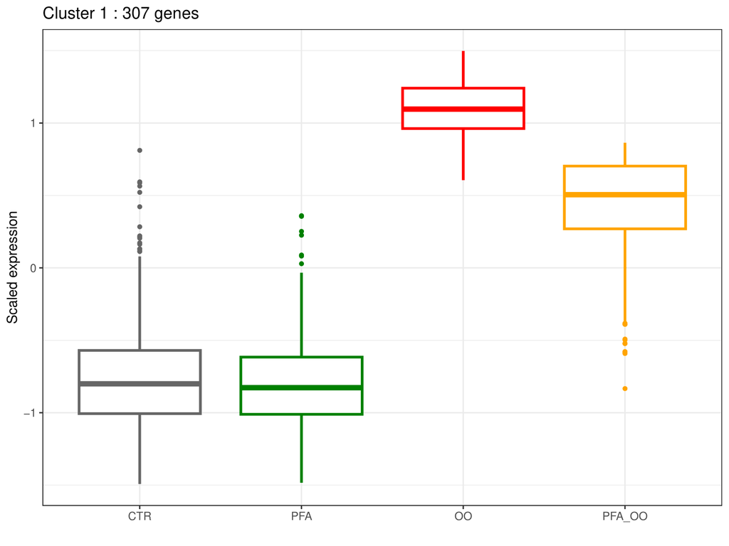

Figure 2B ranks enriched GO terms for cluster 1 by adjusted significance. Locally reproduced enrichment themes include lipid oxidation, fatty acid oxidation, organic acid metabolism, and mitochondrial structures — coherent with the known liver response to oxidized dietary lipids.

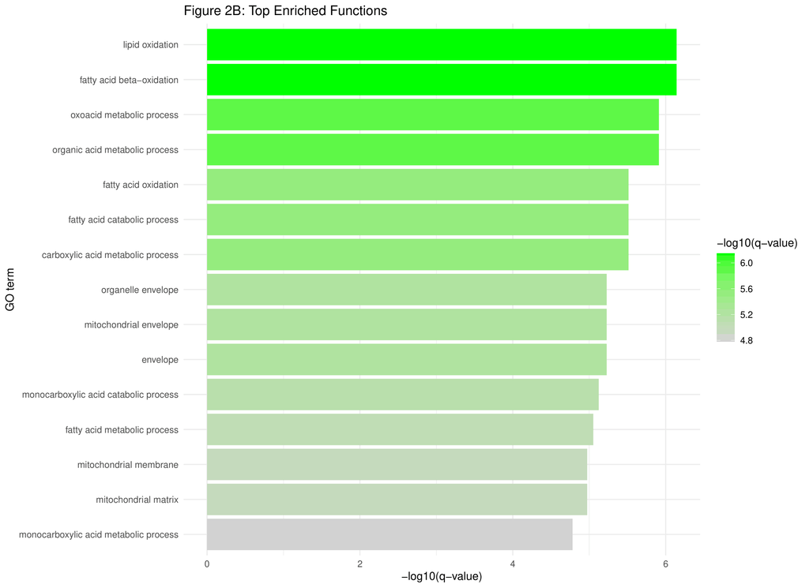

The pattern should be read as a transcriptomic signature of challenge and partial mitigation, not as direct evidence of reduced biochemical peroxidation. RNA-seq measures transcript abundance, not enzyme activity or metabolite concentration. The interpretation is strengthened by the biological plausibility of the enriched terms and by the qPCR validation reported in the original paper. The cluster-level approach also guards against overemphasis on individual outlier genes: the conclusion rests on many functionally related genes moving together, not on any single large fold change.

## Comparison With the Paper

| Component | Paper | Project |
| --- | --- | --- |
| Workflow manager | Snakemake | Nextflow DSL2 |
| Genome alignment | STAR, Sscrofa11.1 | STAR, Ensembl Sscrofa11.1 release 111 |
| Gene counting | HTSeq after STAR | STAR GeneCounts, reverse-stranded column |
| Differential expression | DESeq2 LRT, four diets | DESeq2 LRT, `~ condition` vs `~ 1` |
| Gene set for clustering | Adj. p ≤ 0.1; 2,762 genes | Adj. p < 0.1, top 2,762 by p-value |
| Clustering | DEGreport `degPatterns` | DEGreport `degPatterns`, min. cluster size 50 |
| Enrichment ID mapping | BioMart | NCBI gene2ensembl + `org.Ss.eg.db` |

The key scientific choices are fully preserved: same biological system, four liver groups, global LRT strategy, clustering package, adjusted p-value level, and focus on cluster 1 enrichment. Differences are implementation-level and typical for a reproduction workflow.

## Quality Control Considerations

FastQC reports flag issues such as low base quality, adapter contamination, or polyA artifacts before alignment. The paper noted base-distribution bias and heavy polyA tail selection in the excluded sample. Alignment statistics provide a second layer: unique mapping percentages from STAR logs feed directly into sample filtering.

Useful extensions not currently implemented include sample-to-sample distance heatmaps and PCA after variance-stabilizing transformation, which would complement the cluster-level plots with sample-level quality views. The paper reports PCA separation between OO and PFA_OO liver samples.

## Reproducibility and Limitations

Key reproducibility strengths are the configuration-driven design — condition order, sample IDs, mapping threshold, p-value cutoff, gene count, and enrichment parameters are all stored in `nextflow.config` — and a modular output structure separating reference files, QC reports, counts, statistics, and figures.

Three limitations apply. First, public databases change over time: the Ensembl release is fixed, but NCBI gene2ensembl and annotation package contents may drift, so a fully frozen reproduction would archive the exact mapping file used. Second, the HTSeq-to-STAR GeneCounts switch means exact numerical identity with the publication cannot be assumed. Third, the workflow covers only the liver component; the ileum GSEA analysis used different statistical logic and is out of scope for this report.

## References

Le Coz, J., Ilic, S., Fibi-Smetana, S., Schatzmayr, G., Zaunschirm, M., and Grenier, B. (2021). Exploring With Transcriptomic Approaches the Underlying Mechanisms of an Essential Oil-Based Phytogenic in the Small Intestine and Liver of Pigs. *Frontiers in Veterinary Science*, 8:650732. DOI: [10.3389/fvets.2021.650732](https://www.frontiersin.org/journals/veterinary-science/articles/10.3389/fvets.2021.650732/full)

Project source files used: `README.md`, `nextflow.config`, `main.nf`, `metadata/SraRunTable.csv`, `modules/star_align.nf`, `modules/recreate_fig2a.nf`, `modules/functional_enrichment.nf`.